# Homework_1

Ruoyuan Qian

2019/9/15

# Problem 1

## a)

I found that there are two rows of variable names which may cause some errors when reading the data into R. As a result, I use `skip=` to skip first row and read others into R.

```r
library(readxl)

#raw_data <- read.table('C:\\Users\\hp\\Desktop\\Biostats\\homework\\Exercise 11.txt',header =TRUE,skip = 1)
 raw_data<-read_excel("C:\\Users\\hp\\Desktop\\Biostats\\homework\\Exercise.xlsx",skip =1)

#check variables and values in raw_data
 str(raw_data)
```

```
## Classes 'tbl_df', 'tbl' and 'data.frame':    72 obs. of  20 variables:
##  $ Group     : num  1 1 1 1 1 1 1 1 1 1 ...
##  $ Age       : num  57 65 61 54 64 41 59 57 67 44 ...
##  $ Gender    : num  1 1 1 2 1 2 1 2 1 2 ...
##  $ Race      : num  1 1 1 2 1 1 1 2 1 1 ...
##  $ HTN       : num  1 1 1 1 1 0 1 0 1 0 ...
##  $ T2DM      : num  0 1 0 1 1 0 1 0 1 0 ...
##  $ Depression: num  0 0 0 0 0 1 0 0 0 0 ...
##  $ Smokes    : num  0 0 0 0 0 0 0 0 0 0 ...
##  $ PRE...9   : num  160 126 120 140 148 116 142 123 160 106 ...
##  $ POST...10 : num  163 92 121 121 123 130 121 113 124 111 ...
##  $ PRE...11  : num  102 59 67 81 63 82 69 77 81 65 ...
##  $ POST...12 : num  107 57 68 65 58 87 68 65 80 65 ...
##  $ PRE...13  : num  33 25.7 26.1 41.6 29.2 31.7 27.6 25.7 36.6 32.3 ...
##  $ POST...14 : num  32.7 25.7 25.3 39.7 28.4 31.3 28.4 25.8 35.6 31.9 ...
##  $ PRE...15  : num  60 40 88 44 48 66 37 69 40 45 ...
##  $ POST...16 : num  62 43 67 24 52 56 44 73 35 49 ...
##  $ PRE...17  : num  110 133 114 112 63 62 89 117 77 126 ...
##  $ POST...18 : num  107 96 98 75 58 86 81 129 73 131 ...
##  $ PRE...19  : num  96 106 92 401 96 75 66 96 113 91 ...
##  $ POST...20 : num  105 132 95 162 216 92 72 71 101 92 ...
```

```r
#check if there is a missing value
 anyNA(raw_data)
```

```
## [1] FALSE
```

```r
#only 3 kinds of race in the data
 table(raw_data$Race)
```

```
##
##  1  2  3
## 51 19  2
```

```r
 library(dplyr)
```

```r
library(arsenal)

#rename some values into a readable way
 fixed_data    <-     raw_data %>% mutate(
         Group  =     recode(Group,  "0" = "Intervention", "1" = "Control"),
         Gender =     recode(Gender, "1" = "male", "2" = "female"),
         HTN    =     recode(HTN,    "0" = "no",   "1" = "yes"),
         T2DM   =     recode(T2DM,   "0" = "no",   "1" = "yes"),
         Smokes =     recode(Smokes, "0" = "no",   "1" = "yes"),
         Depression = recode(Depression, "0" = "no", "1" = "yes"),
         Race   =     recode(Race,   "1" = "African American",
                                     "2" = "Hispanic",
                                     "3" = "African American"))

#draw the descriptive table
 sum_data  <-  arsenal::tableby(Group ~ Age + Gender + Race + Depression + Smokes + HTN+T2DM,
                       data  = fixed_data,
                       test  = FALSE,
                       total = FALSE,
                       numeric.stats = c("meansd" ,"median" ) )
 summary(sum_data,text = TRUE)
```

```
##
##
## |                    | Control (N=36) | Intervention (N=36) |
## |:-------------------|:--------------:|:-------------------:|
## |Age                 |                |                     |
## |-  Mean (SD)        | 53.583 (9.581) |   51.500 (10.809)   |
## |-  Median           |     55.500     |       51.000        |
## |Gender              |                |                     |
## |-  female           |   20 (55.6%)   |     20 (55.6%)      |
## |-  male             |   16 (44.4%)   |     16 (44.4%)      |
## |Race                |                |                     |
## |-  African American |   31 (86.1%)   |     22 (61.1%)      |
## |-  Hispanic         |   5 (13.9%)    |     14 (38.9%)      |
## |Depression          |                |                     |
## |-  no               |   26 (72.2%)   |     23 (63.9%)      |
## |-  yes              |   10 (27.8%)   |     13 (36.1%)      |
## |Smokes              |                |                     |
## |-  no               |   31 (86.1%)   |     31 (86.1%)      |
## |-  yes              |   5 (13.9%)    |      5 (13.9%)      |
## |HTN                 |                |                     |
## |-  no               |   14 (38.9%)   |     16 (44.4%)      |
## |-  yes              |   22 (61.1%)   |     20 (55.6%)      |
## |T2DM                |                |                     |
## |-  no               |   23 (63.9%)   |     17 (47.2%)      |
## |-  yes              |   13 (36.1%)   |     19 (52.8%)      |
```

## b)

### b) i

```r
# merge BMI_PRE and BMI_POST into one column
  a <- dplyr::select(fixed_data, c(Group,PRE...13 ))
  b <- dplyr::select(fixed_data, c(Group,POST...14))
  bmi_pre  <- rename(a,BMI=PRE...13 )
  bmi_post <- rename(b,BMI=POST...14)

# add a new variable that helps to illustrate time status of BMI, either baseline or  post-measurement
  len_pre  <- length(bmi_pre$Group)
  len_post <- length(bmi_pre$Group)
  data_b   <- rbind(cbind(bmi_pre, time=rep(0,len_pre )),
                    cbind(bmi_post,time=rep(1,len_post)))
  data_bmi <- data_b %>% mutate(
              time = recode(time, "0" = "baseline",
                                  "1" = "post-measurement"))
 int_pre<-filter(data_bmi, Group=="Intervention" ,time=="baseline")
 int_post<-filter(data_bmi, Group=="Intervention" ,time=="post-measurement")
 con_pre<-filter(data_bmi, Group=="Control" ,time=="baseline")
 con_post<-filter(data_bmi, Group=="Control" ,time=="post-measurement")

 mean_int_pre<- mean( int_pre$BMI)
 mean_int_post<- mean( int_post$BMI)
 sd_int_pre<-sd(int_pre$BMI)
 sd_int_post<-sd(int_post$BMI)

 mean_con_pre<- mean( con_pre$BMI)
 mean_con_post<- mean( con_post$BMI)
 sd_con_pre<-sd(con_pre$BMI)
 sd_con_post<-sd(con_post$BMI)

 abs(max((mean_int_pre+sd_int_pre),(mean_int_post+sd_int_post))-
       min((mean_int_pre-sd_int_pre),(mean_int_post-sd_int_post)))
```

```
## [1] 12.413
```

### b) ii

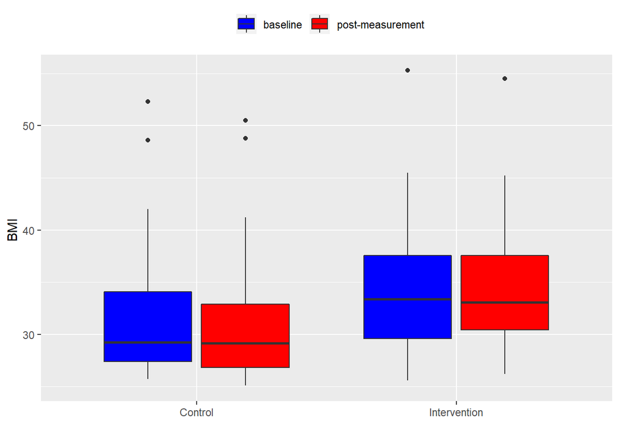

```r
# draw side by side boxplot of BMI
library(ggplot2)
  ggplot(data_bmi,aes(x = Group, y = BMI, fill = time)) +
   geom_boxplot() +
   scale_fill_manual(values = c("blue", "red"),
                     labels  = expression("baseline", "post-measurement")) +
  xlab("") +
  ylab("BMI ") +
 theme(legend.position = "top", legend.title = element_blank())
```

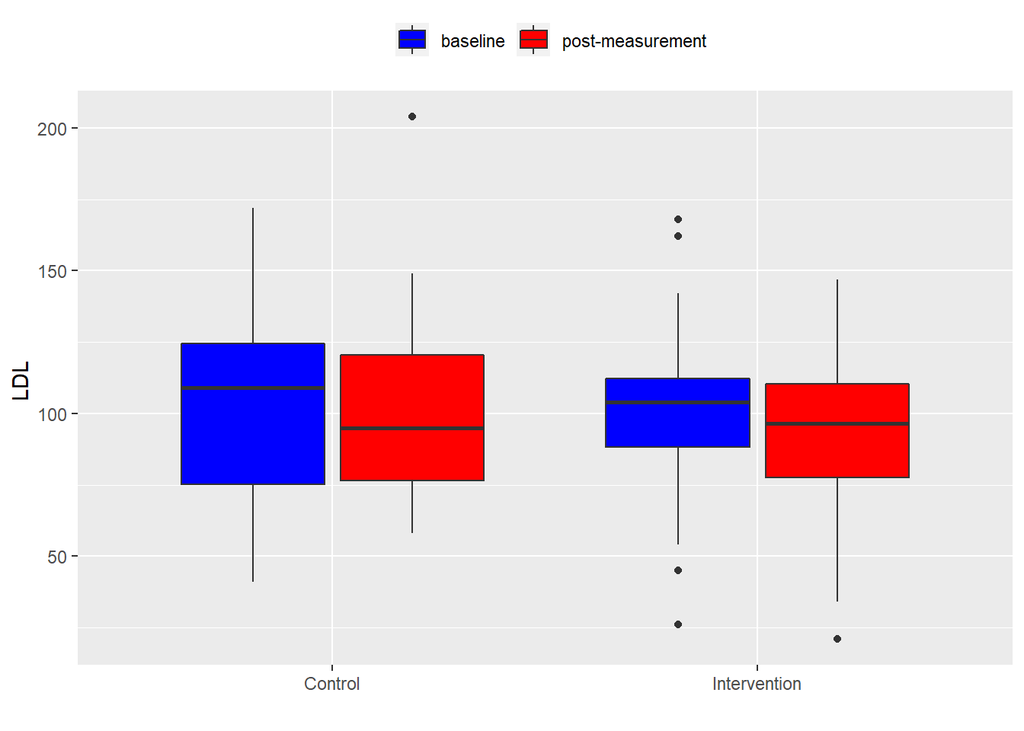

```r
# merge DLD_PRE and DLD_POST into one column
 a1 <- dplyr::select(fixed_data, c(Group,PRE...17 ))
 b1 <- dplyr::select(fixed_data, c(Group,POST...18))
 ldl_pre  <- rename( a1,LDL = PRE...17 )
 ldl_post <- rename( b1,LDL = POST...18)

# add a new variable that helps to illustrate time status of DLD, either baseline or  post-measurement
 len_pre  <- length( ldl_pre$Group  )
 len_post <- length( ldl_pre$Group  )
 data_l   <- rbind(  cbind(ldl_pre,time=rep(0,len_pre)),
                     cbind(ldl_post,time=rep(1,len_post)))
 data_ldl <- data_l %>% mutate(
             time = recode(time, "0" = "baseline",
                                 "1" = "post-measurement"))

 # draw side by side boxplot of LDL
 ggplot(data_ldl,
        aes(x = Group, y = LDL, fill = time)) +
  geom_boxplot() +
 scale_fill_manual(values = c("blue", "red"),
                     labels = expression("baseline", "post-measurement")) +
 xlab("") +
  ylab("LDL ")  +
theme(legend.position = "top", legend.title = element_blank())
```

### b) iii

As for the BMI in the study, in general, the values in intervention group are higher than the control group’s while there is little difference of values within each group.

As for the LDL, for both groups, there is a trend that the values in post measurement are lower than the baseline’s, and it is more obvious in control. Besides, in intervention , the values are more concentrated whereas values in control are more dispersed.